# Flu Shot Learning

## Context

The DrivenData website launched a data competition on [H1N1 and seasonal flu vaccination](https://www.drivendata.org/competitions/66/flu-shot-learning/page/210/). The objective is to predict how likely individuals are to receive their flu vaccines based on data and information collected in a phone survey.

## Setup

```r
knitr::opts_chunk$set(echo = TRUE)
rm(list = ls())
```

```r
if (!require("pacman")) install.packages("pacman")
```

```r
pacman::p_load(tidyverse, janitor, magrittr, cowplot, tidymodels)
#theme_set(theme_minimal())
```

## Data

Data were downloaded from the [website](https://www.drivendata.org/competitions/66/flu-shot-learning/data/) on April 14th, 2020.

```r
train_features <- read_csv("~/projects/driven_data/flu_shot/data/raw/training_set_features.csv")
train_labels <- read_csv("~/projects/driven_data/flu_shot/data/raw/training_set_labels.csv")
test_features <- read_csv("~/projects/driven_data/flu_shot/data/raw/test_set_features.csv")
submission_format <- read_csv("~/projects/driven_data/flu_shot/data/raw/submission_format.csv")
```

## Initial exploration

```r
dim(train_features)
```

```
## [1] 26707    36
```

```r
dim(train_labels)
```

```
## [1] 26707     3
```

```r
dim(test_features)
```

```
## [1] 26708    36
```

```r
dim(submission_format)
```

```
## [1] 26708     3
```

From the above we can see that the training datasets have 26707 rows (using the head and tail functions we can see that those rows correspond to respondant_id 0 to 26706) and the test datasets has 26708 rows (respondant_id 26707 to 53414). We can also see that features for both the training and testing datasets include 36 variables and a quick verification with the intersect function confirmed that the variables are the same for the training and testing datasets.

```r
intersect(names(train_features), names(test_features))
```

```
##  [1] "respondent_id"               "h1n1_concern"
##  [3] "h1n1_knowledge"              "behavioral_antiviral_meds"
##  [5] "behavioral_avoidance"        "behavioral_face_mask"
##  [7] "behavioral_wash_hands"       "behavioral_large_gatherings"
##  [9] "behavioral_outside_home"     "behavioral_touch_face"
## [11] "doctor_recc_h1n1"            "doctor_recc_seasonal"
## [13] "chronic_med_condition"       "child_under_6_months"
## [15] "health_worker"               "health_insurance"
## [17] "opinion_h1n1_vacc_effective" "opinion_h1n1_risk"
## [19] "opinion_h1n1_sick_from_vacc" "opinion_seas_vacc_effective"
## [21] "opinion_seas_risk"           "opinion_seas_sick_from_vacc"
## [23] "age_group"                   "education"
## [25] "race"                        "sex"
## [27] "income_poverty"              "marital_status"
## [29] "rent_or_own"                 "employment_status"
## [31] "hhs_geo_region"              "census_msa"
## [33] "household_adults"            "household_children"
## [35] "employment_industry"         "employment_occupation"
```

Using the same function we can confirm that the only common variable to the features and labels datasets are the respondant_id:

```r
intersect(names(train_features), names(train_labels))
```

```
## [1] "respondent_id"
```

```r
intersect(names(test_features), names(submission_format))
```

```
## [1] "respondent_id"
```

We can therefore join the features and labels of the training datasets resulting in the same number of rows with two additional variables being h1n1_vaccine and seasonal_vaccine (the ones to prdict in the test dataset):

```r
train_all <- train_labels %>% left_join(train_features)
dim(train_all)
```

```
## [1] 26707    38
```

```r
head(train_all)
```

```
## # A tibble: 6 x 38
##   respondent_id h1n1_vaccine seasonal_vaccine h1n1_concern h1n1_knowledge
##           <dbl>        <dbl>            <dbl>        <dbl>          <dbl>
## 1             0            0                0            1              0
## 2             1            0                1            3              2
## 3             2            0                0            1              1
## 4             3            0                1            1              1
## 5             4            0                0            2              1
## 6             5            0                0            3              1
## # … with 33 more variables: behavioral_antiviral_meds <dbl>,
## #   behavioral_avoidance <dbl>, behavioral_face_mask <dbl>,
## #   behavioral_wash_hands <dbl>, behavioral_large_gatherings <dbl>,
## #   behavioral_outside_home <dbl>, behavioral_touch_face <dbl>,
## #   doctor_recc_h1n1 <dbl>, doctor_recc_seasonal <dbl>,
## #   chronic_med_condition <dbl>, child_under_6_months <dbl>,
## #   health_worker <dbl>, health_insurance <dbl>,
## #   opinion_h1n1_vacc_effective <dbl>, opinion_h1n1_risk <dbl>,
## #   opinion_h1n1_sick_from_vacc <dbl>, opinion_seas_vacc_effective <dbl>,
## #   opinion_seas_risk <dbl>, opinion_seas_sick_from_vacc <dbl>,
## #   age_group <chr>, education <chr>, race <chr>, sex <chr>,
## #   income_poverty <chr>, marital_status <chr>, rent_or_own <chr>,
## #   employment_status <chr>, hhs_geo_region <chr>, census_msa <chr>,
## #   household_adults <dbl>, household_children <dbl>,
## #   employment_industry <chr>, employment_occupation <chr>
```

The [data for this competition comes from the National 2009 H1N1 Flu Survey (NHFS)](https://www.drivendata.org/competitions/66/flu-shot-learning/page/213/). In their own words:

> The National 2009 H1N1 Flu Survey (NHFS) was sponsored by the National Center for Immunization and Respiratory Diseases (NCIRD) and conducted jointly by NCIRD and the National Center for Health Statistics (NCHS), Centers for Disease Control and Prevention (CDC). The NHFS was a list-assisted random-digit-dialing telephone survey of households, designed to monitor influenza immunization coverage in the 2009-10 season. The target population for the NHFS was all persons 6 months or older living in the United States at the time of the interview. Data from the NHFS were used to produce timely estimates of vaccination coverage rates for both the monovalent pH1N1 and trivalent seasonal influenza vaccines.

### Data description

The description for the variables below are from the [DrivenData](https://www.drivendata.org/competitions/66/flu-shot-learning/page/211/) website:

There are two target variables (multilabel problem) and both are binary variables(0 = No; 1 = Yes):

- h1n1_vaccine - Whether respondent received H1N1 flu vaccine.
- seasonal_vaccine - Whether respondent received seasonal flu vaccine.

There are 36 features in this dataset, hence a dataset with 36 columns. The first column respondent_id is a unique and random identifier. The remaining 35 features are described below. For all binary variables: 0 = No; 1 = Yes.

- h1n1_concern - Level of concern about the H1N1 flu.
  - 0 = Not at all concerned; 1 = Not very concerned; 2 = Somewhat concerned; 3 = Very concerned.
- h1n1_knowledge - Level of knowledge about H1N1 flu.
  - 0 = No knowledge; 1 = A little knowledge; 2 = A lot of knowledge.
- behavioral_antiviral_meds - Has taken antiviral medications. (binary)
- behavioral_avoidance - Has avoided close contact with others with flu-like symptoms. (binary)
- behavioral_face_mask - Has bought a face mask. (binary)
- behavioral_wash_hands - Has frequently washed hands or used hand sanitizer. (binary)
- behavioral_large_gatherings - Has reduced time at large gatherings. (binary)
- behavioral_outside_home - Has reduced contact with people outside of own household. (binary)
- behavioral_touch_face - Has avoided touching eyes, nose, or mouth. (binary)
- doctor_recc_h1n1 - H1N1 flu vaccine was recommended by doctor. (binary)
- doctor_recc_seasonal - Seasonal flu vaccine was recommended by doctor. (binary)
- chronic_med_condition - Has any of the following chronic medical conditions: asthma or an other lung condition, diabetes, a heart condition, a kidney condition, sickle cell anemia or other anemia, a neurological or neuromuscular condition, a liver condition, or a weakened immune system caused by a chronic illness or by medicines taken for a chronic illness. (binary)
- child_under_6_months - Has regular close contact with a child under the age of six months. (binary)
- health_worker - Is a healthcare worker. (binary)
- health_insurance - Has health insurance. (binary)
- opinion_h1n1_vacc_effective - Respondent’s opinion about H1N1 vaccine effectiveness.
  - 1 = Not at all effective; 2 = Not very effective; 3 = Don’t know; 4 = Somewhat effective; 5 = Very effective.
- opinion_h1n1_risk - Respondent’s opinion about risk of getting sick with H1N1 flu without vaccine.
  - 1 = Very Low; 2 = Somewhat low; 3 = Don’t know; 4 = Somewhat high; 5 = Very high.
- opinion_h1n1_sick_from_vacc - Respondent’s worry of getting sick from taking H1N1 vaccine.
  - 1 = Not at all worried; 2 = Not very worried; 3 = Don’t know; 4 = Somewhat worried; 5 = Very worried.
- opinion_seas_vacc_effective - Respondent’s opinion about seasonal flu vaccine effectiveness.
  - 1 = Not at all effective; 2 = Not very effective; 3 = Don’t know; 4 = Somewhat effective; 5 = Very effective.
- opinion_seas_risk - Respondent’s opinion about risk of getting sick with seasonal flu without vaccine.
  - 1 = Very Low; 2 = Somewhat low; 3 = Don’t know; 4 = Somewhat high; 5 = Very high.
- opinion_seas_sick_from_vacc - Respondent’s worry of getting sick from taking seasonal flu vaccine.
  - 1 = Not at all worried; 2 = Not very worried; 3 = Don’t know; 4 = Somewhat worried; 5 = Very worried.
- age_group - Age group of respondent.
- education - Self-reported education level.
- race - Race of respondent.
- sex - Sex of respondent.
- income_poverty - Household annual income of respondent with respect to 2008 Census poverty thresholds.
- marital_status - Marital status of respondent.
- rent_or_own - Housing situation of respondent.
- employment_status - Employment status of respondent.
- hhs_geo_region - Respondent’s residence using a 10-region geographic classification defined by the U.S. Dept. of Health and Human Services. Values are represented as short random character strings.
- census_msa - Respondent’s residence within metropolitan statistical areas (MSA) as defined by the U.S. Census.
- household_adults - Number of other adults in household, top-coded to 3.
- household_children - Number of children in household, top-coded to 3.
- employment_industry - Type of industry respondent is employed in. Values are represented as short random character strings.
- employment_occupation - Type of occupation of respondent. Values are represented as short random character strings.

```r
# magrittr
train_all %<>% mutate_all(as.factor)
train_all %<>% mutate(respondent_id = as.integer(respondent_id))
```

```r
str(train_all$h1n1_vaccine)
```

```
##  Factor w/ 2 levels "0","1": 1 1 1 1 1 1 1 2 1 1 ...
```

```r
percent_h1n1 <- train_all %>%
  tabyl(h1n1_vaccine)
percent_h1n1
```

```
##  h1n1_vaccine     n   percent
##             0 21033 0.7875463
##             1  5674 0.2124537
```

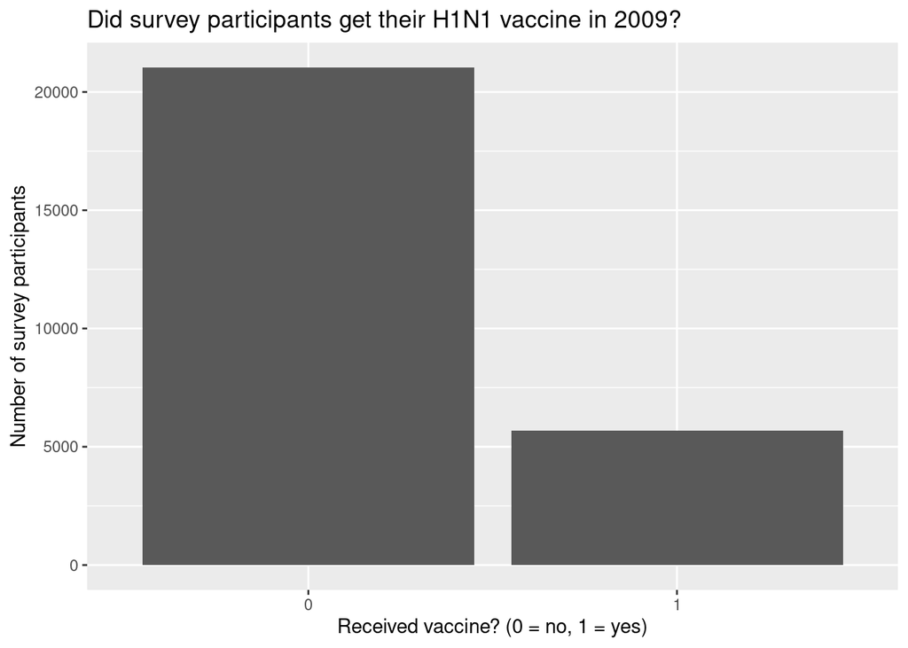

```r
percent_h1n1 %>%
  ggplot() +
  geom_col(aes(y = n, x = h1n1_vaccine)) +
  labs(x = "Received vaccine? (0 = no, 1 = yes)",
       y = "Number of survey participants",
       title = "Did survey participants get their H1N1 vaccine in 2009?")
```

```r
str(train_all$seasonal_vaccine)
```

```
##  Factor w/ 2 levels "0","1": 1 2 1 2 1 1 1 2 1 1 ...
```

```r
percent_seasonal <- train_all %>%
  tabyl(seasonal_vaccine)
percent_seasonal
```

```
##  seasonal_vaccine     n   percent
##                 0 14272 0.5343917
##                 1 12435 0.4656083
```

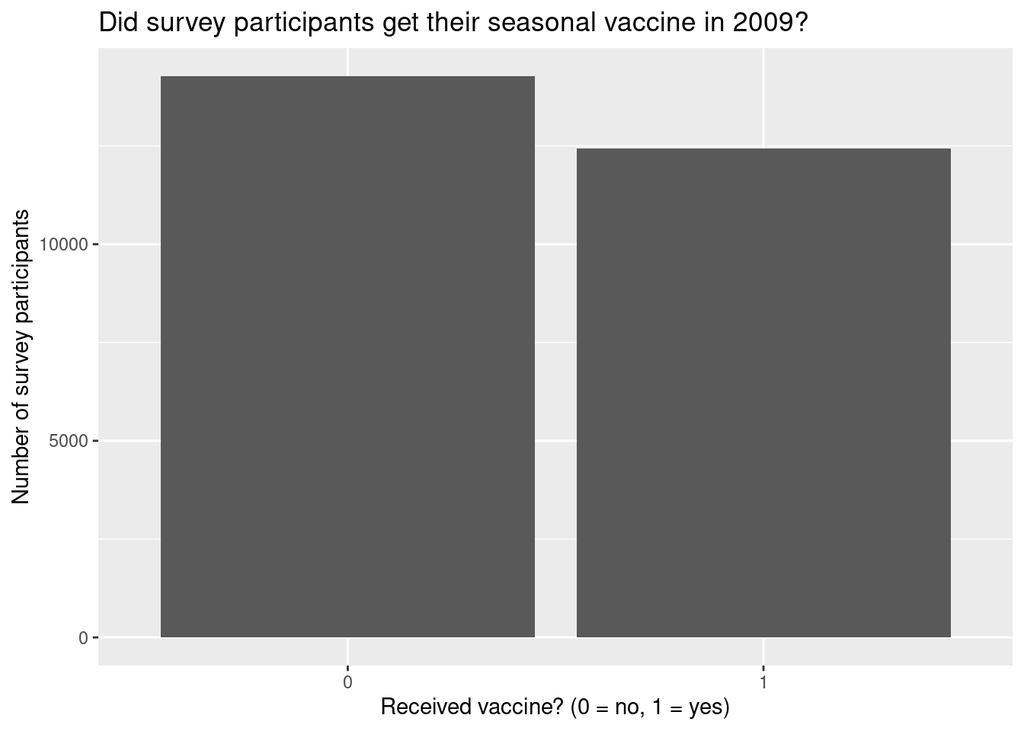

```r
percent_seasonal%>%
  ggplot() +
  geom_col(aes(y = n, x = seasonal_vaccine)) +
  labs(x = "Received vaccine? (0 = no, 1 = yes)",
       y = "Number of survey participants",
       title = "Did survey participants get their seasonal vaccine in 2009?")
```

There are no missing values for the variables indicating whether the survey participants received their seasonal and/or H1N1 vaccination. Overall, 46.6% of survey participants got their seasonal vaccination while 21.2% got their H1N1 vaccination in 2009.

What if we consider both vaccines? How many participants got either no vaccination, H1N1 vaccine only, seasonal flu vaccine only, both vaccines?

```r
none <- sum(train_all$h1n1_vaccine == 0 & train_all$seasonal_vaccine == 0)
h1n1 <- sum(train_all$h1n1_vaccine == 1 & train_all$seasonal_vaccine == 0)
seasonal <- sum(train_all$h1n1_vaccine == 0 & train_all$seasonal_vaccine == 1)
both <- sum(train_all$h1n1_vaccine == 1 & train_all$seasonal_vaccine == 1)

all <- tibble(
  group = c("none", "H1N1", "seasonal", "both"),
  n = c(none, h1n1, seasonal, both),
)

all <- all %>% add_column(percent = all$n/26707*100)
all
```

```
## # A tibble: 4 x 3
##   group        n percent
##   <chr>    <int>   <dbl>
## 1 none     13295   49.8
## 2 H1N1       977    3.66
## 3 seasonal  7738   29.0
## 4 both      4697   17.6
```

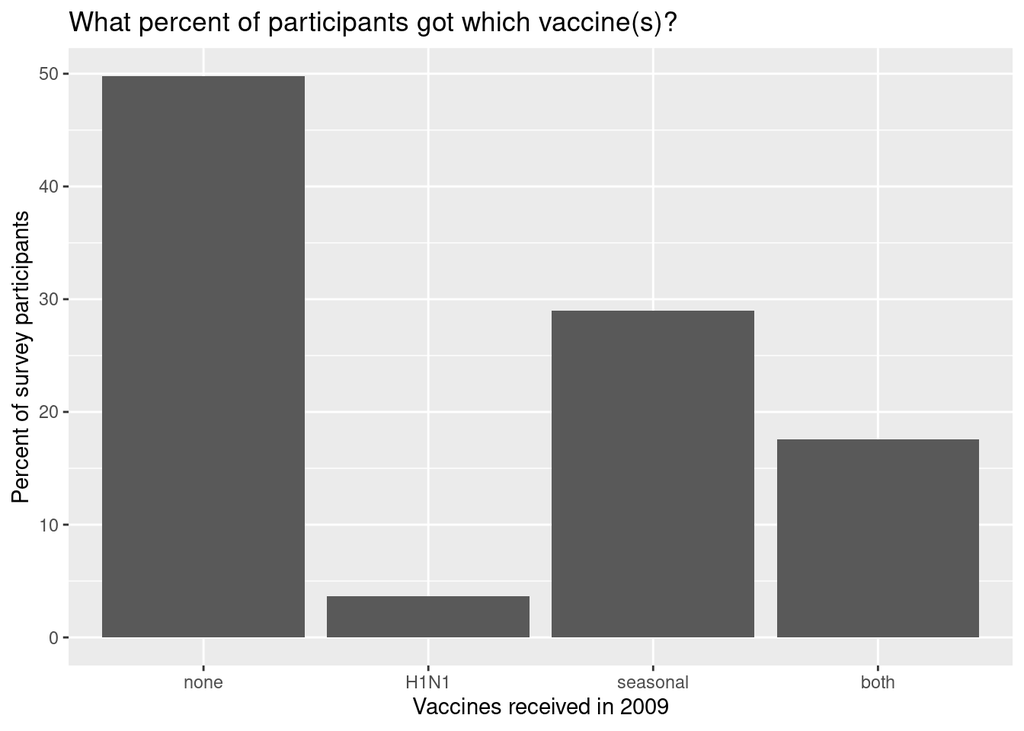

```r
level_order <- c("none", "H1N1", "seasonal", "both")

all %>%
  ggplot() +
  geom_col(aes(x = factor(group, level = level_order), y = percent)) +
  labs(x = "Vaccines received in 2009",
       y = "Percent of survey participants",
       title = "What percent of participants got which vaccine(s)?")
```

### Looking at each variable

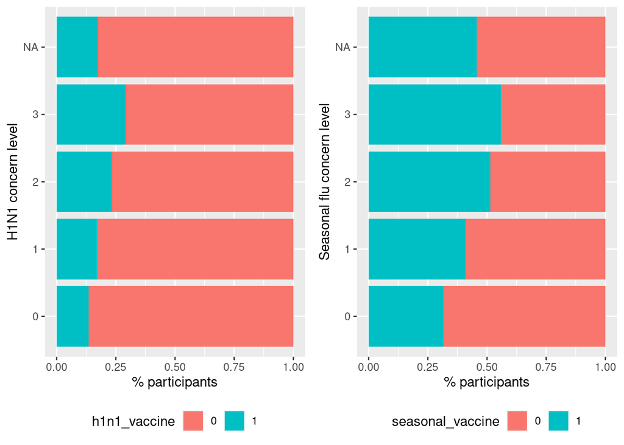

```r
train_all %>%
  ggplot(mapping = aes(y = h1n1_concern, fill = h1n1_vaccine)) +
  geom_bar(position = "fill") +
  labs(x = "% participants",
       y = "H1N1 concern level") +
       theme(legend.position = "bottom") -> A

train_all %>%
  ggplot(mapping = aes(y = h1n1_concern, fill = seasonal_vaccine)) +
  geom_bar(position = "fill") +
  labs(x = "% participants",
       y = "Seasonal flu concern level") +
       theme(legend.position = "bottom") -> B

prow <- plot_grid(
  A, B,
  align = 'vh',
  hjust = -1,
  nrow = 1
)

plot_grid(prow, rel_widths = c(3, .4))
```

```r
parameters <- c("h1n1_concern", "h1n1_knowledge", "behavioral_antiviral_meds", "behavioral_avoidance", "behavioral_face_mask", "behavioral_wash_hands", "behavioral_large_gatherings", "behavioral_outside_home", "behavioral_touch_face", "doctor_recc_h1n1", "doctor_recc_seasonal", "chronic_med_condition", "child_under_6_months", "health_worker", "health_insurance", "opinion_h1n1_vacc_effective", "opinion_h1n1_risk", "opinion_h1n1_sick_from_vacc", "opinion_seas_vacc_effective", "opinion_seas_risk", "opinion_seas_sick_from_vacc", "age_group", "education", "race", "sex", "income_poverty", "marital_status", "rent_or_own", "employment_status", "hhs_geo_region", "census_msa", "household_adults", "household_children", "employment_industry", "employment_occupation")
```

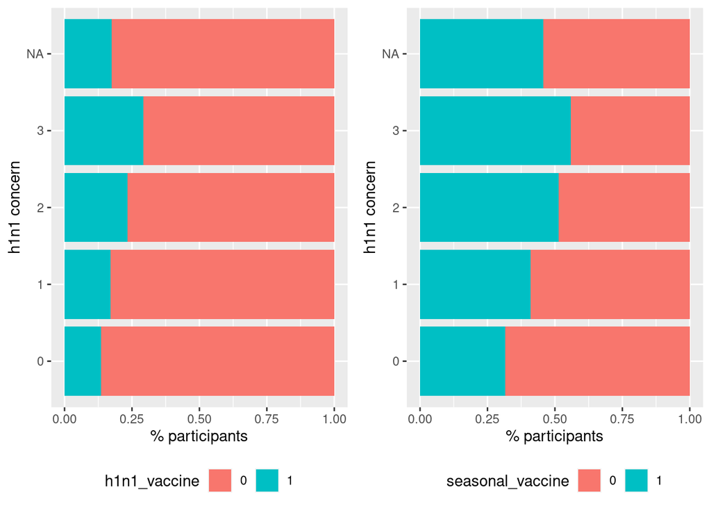

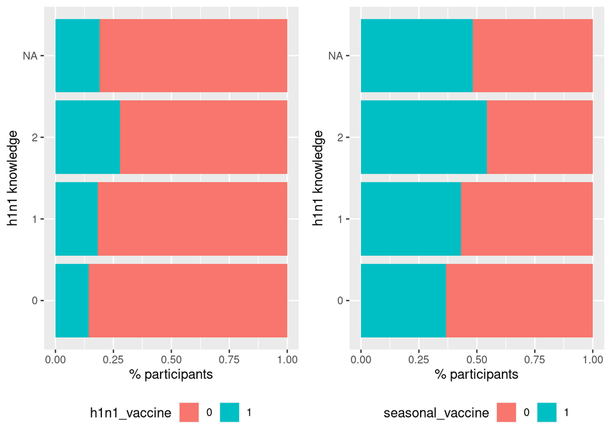

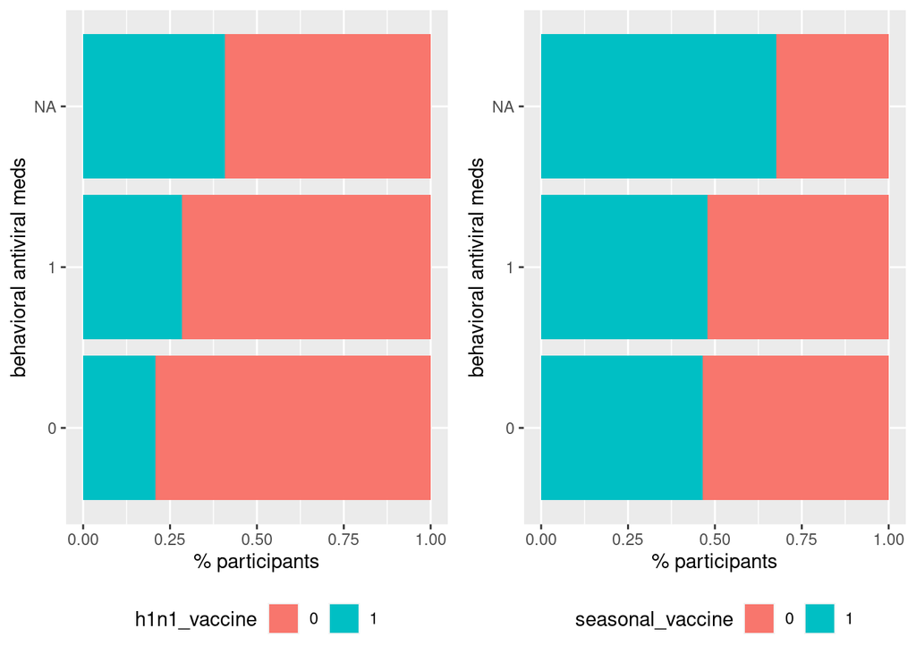

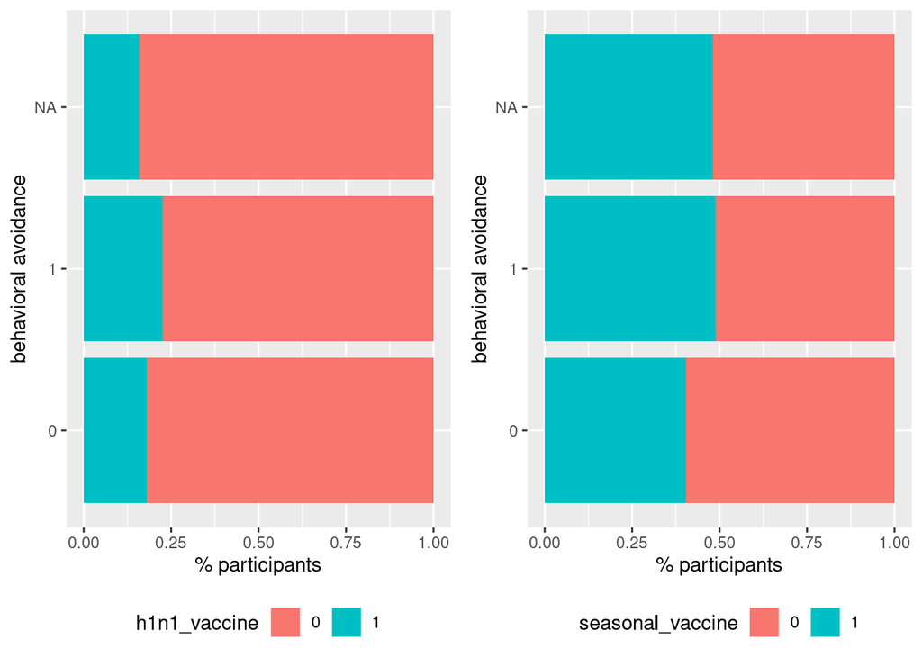

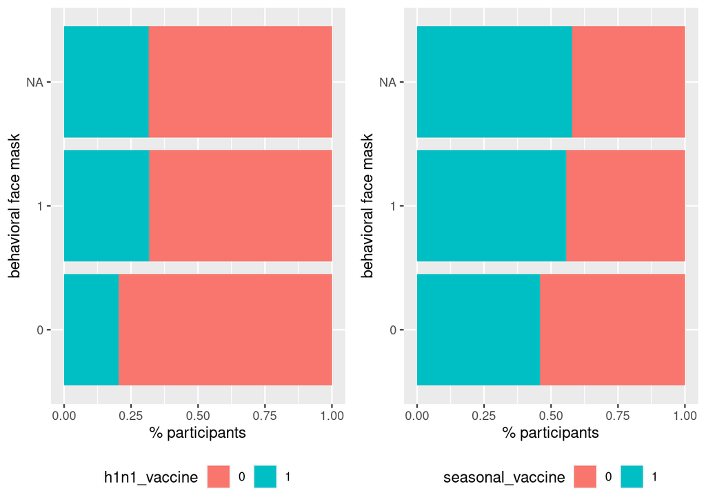

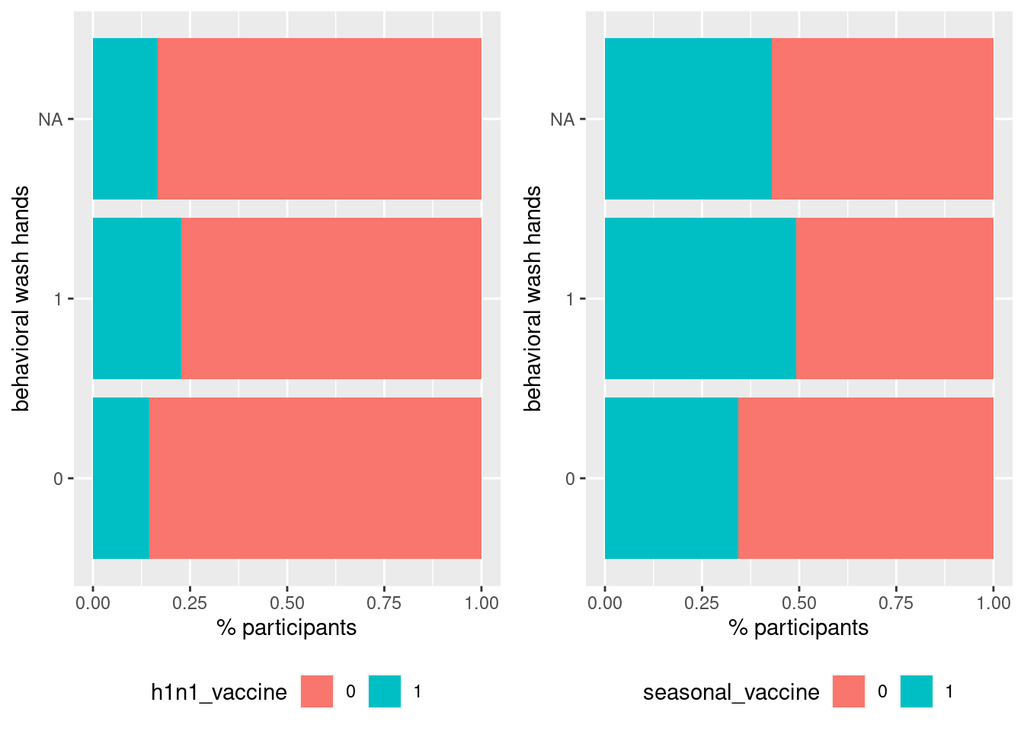

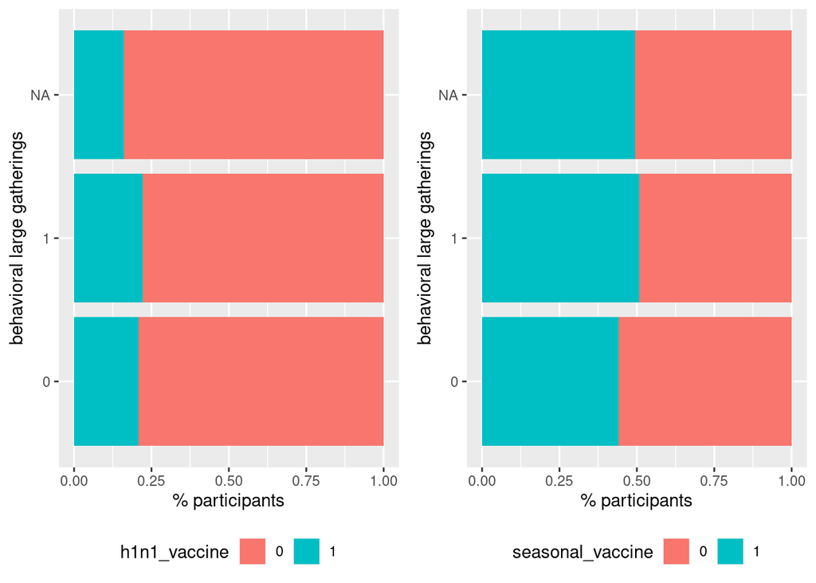

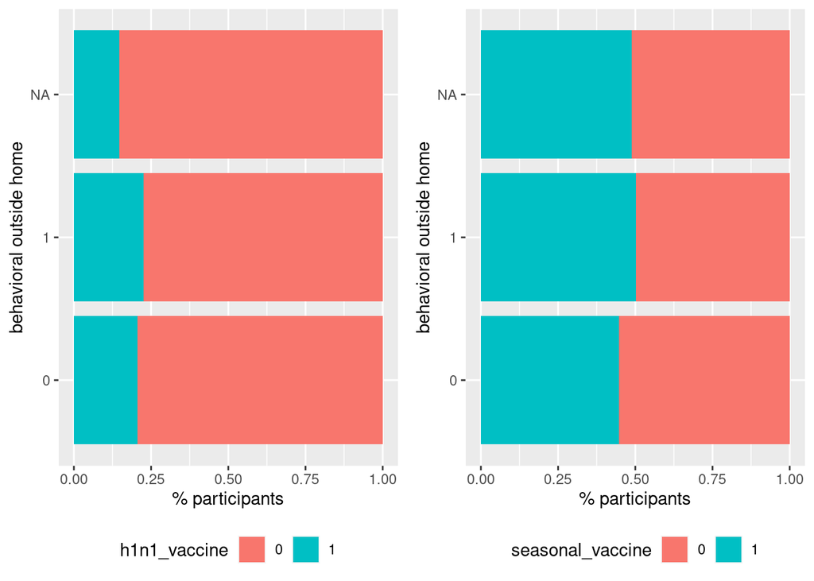

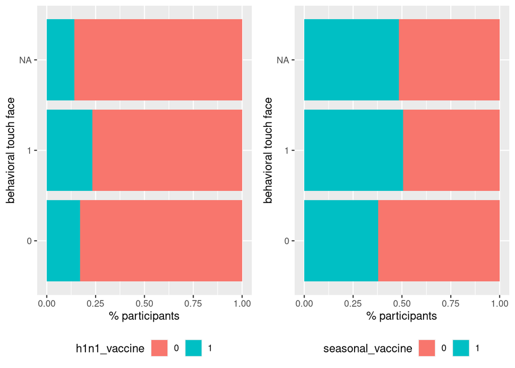

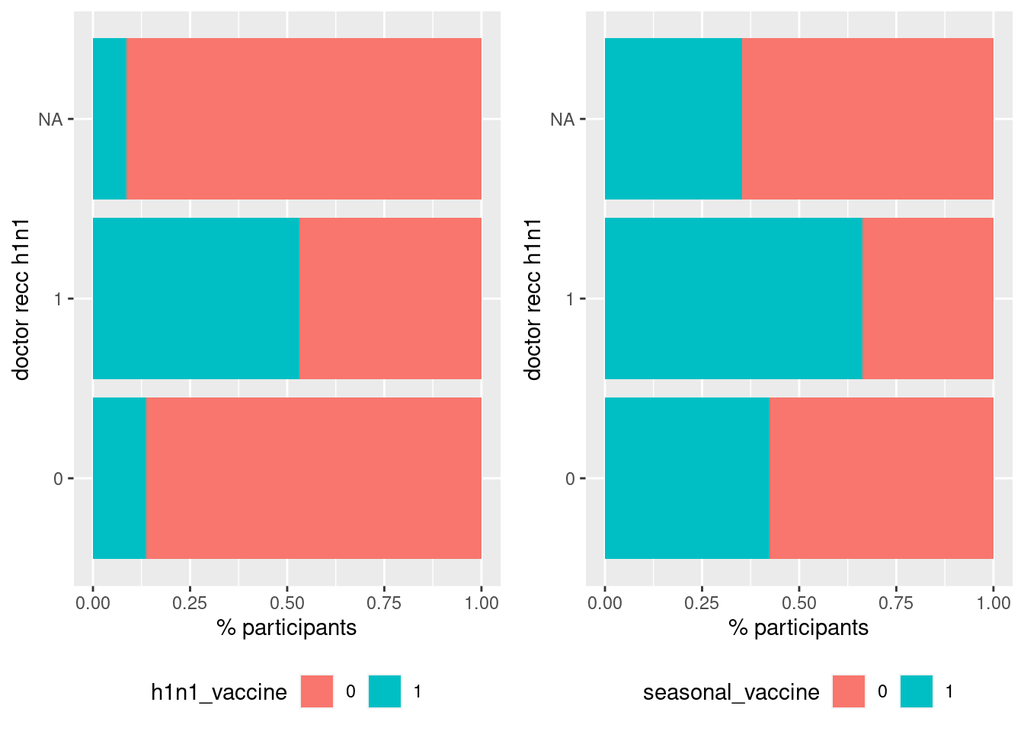

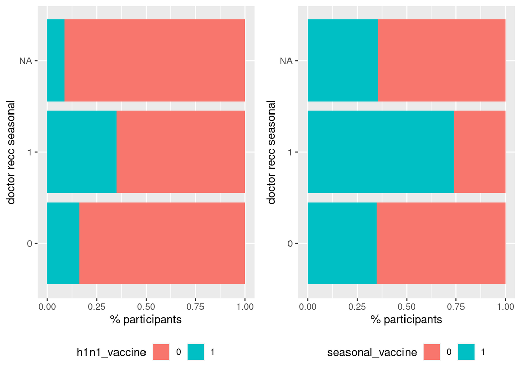

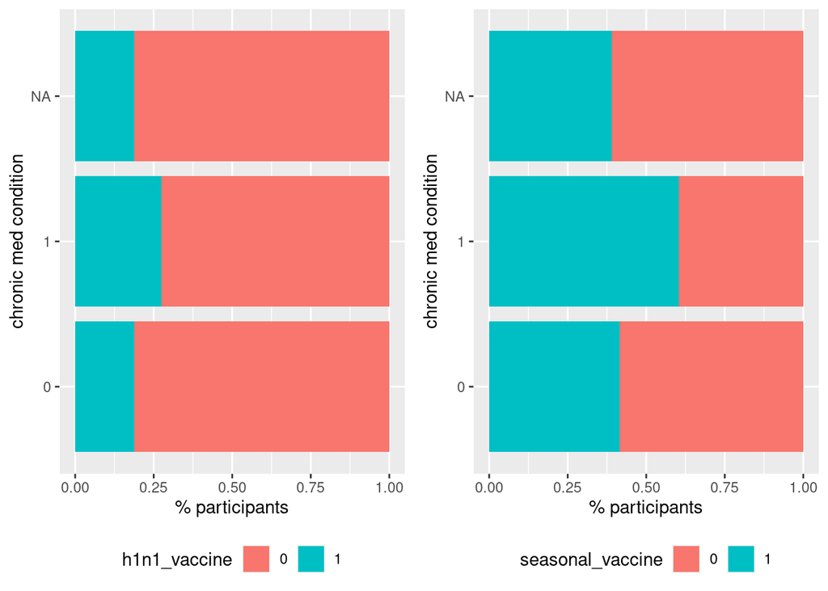

[23 more figures not shown]

```r
lapply(parameters, bar_plot_function)
```

### Missing values

We should acknowledge that the above visualisations we done using the raw data. One could be interested in the number of missing values for each variable in the dataset. First, in the train set:

```r
na_count <- sapply(train_all, function(y) sum(length(which(is.na(y)))))
na_count <- data.frame(na_count)
na_count <- na_count %>%
  add_column(percent_missing = na_count$na_count/26707*100)
na_count
```

```
##                             na_count percent_missing
## respondent_id                      0       0.0000000
## h1n1_vaccine                       0       0.0000000
## seasonal_vaccine                   0       0.0000000
## h1n1_concern                      92       0.3444790
## h1n1_knowledge                   116       0.4343431
## behavioral_antiviral_meds         71       0.2658479
## behavioral_avoidance             208       0.7788220
## behavioral_face_mask              19       0.0711424
## behavioral_wash_hands             42       0.1572621
## behavioral_large_gatherings       87       0.3257573
## behavioral_outside_home           82       0.3070356
## behavioral_touch_face            128       0.4792751
## doctor_recc_h1n1                2160       8.0877673
## doctor_recc_seasonal            2160       8.0877673
## chronic_med_condition            971       3.6357509
## child_under_6_months             820       3.0703561
## health_worker                    804       3.0104467
## health_insurance               12274      45.9579885
## opinion_h1n1_vacc_effective      391       1.4640356
## opinion_h1n1_risk                388       1.4528026
## opinion_h1n1_sick_from_vacc      395       1.4790130
## opinion_seas_vacc_effective      462       1.7298836
## opinion_seas_risk                514       1.9245891
## opinion_seas_sick_from_vacc      537       2.0107088
## age_group                          0       0.0000000
## education                       1407       5.2682817
## race                               0       0.0000000
## sex                                0       0.0000000
## income_poverty                  4423      16.5612012
## marital_status                  1408       5.2720261
## rent_or_own                     2042       7.6459355
## employment_status               1463       5.4779646
## hhs_geo_region                     0       0.0000000
## census_msa                         0       0.0000000
## household_adults                 249       0.9323398
## household_children               249       0.9323398
## employment_industry            13330      49.9120081
## employment_occupation          13470      50.4362152
```

And then, in the test dataset for which we have to predict the labels:

```r
na_count <- sapply(test_features, function(y) sum(length(which(is.na(y)))))
na_count <- data.frame(na_count)
na_count <- na_count %>%
  add_column(percent_missing = na_count$na_count/26708*100)
na_count
```

```
##                             na_count percent_missing
## respondent_id                      0      0.00000000
## h1n1_concern                      85      0.31825670
## h1n1_knowledge                   122      0.45679197
## behavioral_antiviral_meds         79      0.29579152
## behavioral_avoidance             213      0.79751385
## behavioral_face_mask              19      0.07113973
## behavioral_wash_hands             40      0.14976786
## behavioral_large_gatherings       72      0.26958215
## behavioral_outside_home           82      0.30702411
## behavioral_touch_face            128      0.47925715
## doctor_recc_h1n1                2160      8.08746443
## doctor_recc_seasonal            2160      8.08746443
## chronic_med_condition            932      3.48959113
## child_under_6_months             813      3.04403175
## health_worker                    789      2.95417103
## health_insurance               12228     45.78403475
## opinion_h1n1_vacc_effective      398      1.49019021
## opinion_h1n1_risk                380      1.42279467
## opinion_h1n1_sick_from_vacc      375      1.40407369
## opinion_seas_vacc_effective      452      1.69237682
## opinion_seas_risk                499      1.86835405
## opinion_seas_sick_from_vacc      521      1.95072637
## age_group                          0      0.00000000
## education                       1407      5.26808447
## race                               0      0.00000000
## sex                                0      0.00000000
## income_poverty                  4497     16.83765164
## marital_status                  1442      5.39913135
## rent_or_own                     2036      7.62318406
## employment_status               1471      5.50771304
## hhs_geo_region                     0      0.00000000
## census_msa                         0      0.00000000
## household_adults                 225      0.84244421
## household_children               225      0.84244421
## employment_industry            13275     49.70420848
## employment_occupation          13426     50.26958215
```

The respondant_id variable is common to both datasets (training and testing) and has no missing values. The two variables only found in the training dataset, the h1n1_vaccine and the seasonal_vaccine variables, also have no NAs. For the remaining of the variables, we see that trends in missing values seem to be the same in the training and the testing datasets. In both cases, the employment variables (industry and occupation) are missing for approximately 50% of respondants; the health_insurance variable is missing for approximately 46% of respondants; the income variable is missing for almost 17% of respondants; whether the H1N1 or the seasonal vaccines had been recommended by their doctors is missing for 8% of respondants; and whether the respondant owns or rents is missing for almost 8% of respondants. Finally, education, marital status and employment status are also missing for approximately 5% of respondants.

We will have to deal with NAs, but given that they are in both datasets… may want to not use the variables with most missing values?

```r
#train_all_no_nas <-
```

## NEXT STEPS

(Try to create the above plots through a loop.)

The next step is to build a model that, based on survey answers, will predict the float probabilities (ranging between 0.0 and 1.0) of each participant to have taken the H1N1 and/or the seasonal flu shot(s), or in other words the probabilities that a person received each vaccine. As this is a multilabel problem, the submission file should include a probability for each vaccine.

### What is a multilabel problem?

Based on the [scikit learn website](https://scikit-learn.org/stable/modules/multiclass.html), **multilabel classification** assigns to each sample a set of target labels so predicting properties of a data-point that are not mutually exclusive. For example, a text might be about any of religion, politics, finance or education at the same time or none of these. On the opposite, **multiclass classification** means a classification task with more than two classes; e.g., classify a set of images of fruits which may be oranges, apples, or pears. Multiclass classification makes the assumption that each sample is assigned to one and only one label: a fruit can be either an apple or a pear but not both at the same time.

OK, so we have several binary and categorical variables to model probabilities of vaccination.

Given that we are trying to predict whether the participants took the flu, this can be predict with a logistic regression model. This was also the approach that Jay Qi, Senior Scientist at DrivenData took during his workshop at the [goodtechfest.com](https://www.goodtechfest.com/) but implemented in Python 3. This is the same as the benchmark code example on the DrivenData website for [this competition](https://www.drivendata.co/blog/predict-flu-vaccine-data-benchmark/). His pipeline included two pre-processing steps being (1) scaling all variables on the same scales and (2) NA imputation as logistic regresssion cannot deal with NAs. His first pass model included all numerical variables.

I will take a very similar approach here, but implemented in R, and with a selection of variables based on the plots.

## Build models with recipes from Tidymodels

```r
set.seed(1234)
data_split <- initial_split(train_all)
train_data <- training(data_split)
test_data <- testing(data_split)
```

```r
recipe_simple <- function(dataset) {
  recipe(Churn ~ ., data = dataset) %>%
    step_string2factor(all_nominal(), -all_outcomes()) %>%
    prep(data = dataset)
}
```

Recipe for data preprocessing - do not put variables that are correlated into a logistic regression

```r
pre_processing <- recipe(h1n1_vaccine ~ ., data = train_data) %>%
  step_corr(all_numeric()) %>%
  step_dummy(all_nominal(), -all_outcomes()) %>%
  step_zv(all_numeric()) %>%
  step_normalize(all_numeric()) %>% #centering and scaling
  prep()
```

[output not shown]

```r
glm_spec <- logistic_reg() %>%
  set_engine("glm")

glm_fit <- glm_spec %>%
  fit(h1n1_vaccine ~ ., data = juice(pre_processing))

glm_fit
```

```
## parsnip model object
##
## Fit time:  1.5s
##
## Call:  stats::glm(formula = formula, family = stats::binomial, data = data)
##
## Coefficients:
##                          (Intercept)                         respondent_id
##                            -1.654949                              0.057668
##                  seasonal_vaccine_X1                       h1n1_concern_X1
##                             0.925388                             -0.032379
##                      h1n1_concern_X2                       h1n1_concern_X3
##                             0.025428                              0.029610
##                    h1n1_knowledge_X1                     h1n1_knowledge_X2
##                             0.224641                              0.317171
##         behavioral_antiviral_meds_X1               behavioral_avoidance_X1
##                             0.039654                             -0.035713
##              behavioral_face_mask_X1              behavioral_wash_hands_X1
##                             0.107186                              0.021630
##       behavioral_large_gatherings_X1            behavioral_outside_home_X1
##                            -0.036300                             -0.003182
##             behavioral_touch_face_X1                   doctor_recc_h1n1_X1
##                            -0.102556                              0.847067
##              doctor_recc_seasonal_X1              chronic_med_condition_X1
##                            -0.445693                              0.029665
##              child_under_6_months_X1                      health_worker_X1
##                             0.075093                              0.268423
##                  health_insurance_X1        opinion_h1n1_vacc_effective_X2
##                             0.220419                             -0.128108
##       opinion_h1n1_vacc_effective_X3        opinion_h1n1_vacc_effective_X4
##                            -0.027146                              0.200595
##       opinion_h1n1_vacc_effective_X5                  opinion_h1n1_risk_X2
##                             0.529291                              0.274989
##                 opinion_h1n1_risk_X3                  opinion_h1n1_risk_X4
##                             0.209436                              0.736341
##                 opinion_h1n1_risk_X5        opinion_h1n1_sick_from_vacc_X2
##                             0.605974                             -0.072945
##       opinion_h1n1_sick_from_vacc_X3        opinion_h1n1_sick_from_vacc_X4
##                            -0.877268                              0.125529
##       opinion_h1n1_sick_from_vacc_X5        opinion_seas_vacc_effective_X2
```

[output cut: 58 more lines]

```
##                            -0.147026                              0.007767
##         employment_industry_rucpziij          employment_industry_saaquncn
##                             0.083168                              0.075737
##         employment_industry_vjjrobsf          employment_industry_wlfvacwt
##                            -0.083523                             -0.100059
##         employment_industry_wxleyezf          employment_industry_xicduogh
##                             0.046210                             -0.021387
##         employment_industry_xqicxuve        employment_occupation_ccgxvspp
##                            -0.047932                             -0.091651
##  [ reached getOption("max.print") -- omitted 21 entries ]
##
## Degrees of Freedom: 4837 Total (i.e. Null);  4721 Residual
##   (15193 observations deleted due to missingness)
## Null Deviance:       5893
## Residual Deviance: 3342  AIC: 3576
```

```r
knn_spec <- nearest_neighbor() %>%
  set_engine("kknn") %>%
  set_mode("classification")

knn_fit <- knn_spec %>%
  fit(h1n1_vaccine ~ ., data = juice(pre_processing))

knn_fit
```

```
## parsnip model object
##
## Fit time:  10s
##
## Call:
## kknn::train.kknn(formula = formula, data = data, ks = 5)
##
## Type of response variable: nominal
## Minimal misclassification: 0.2715998
## Best kernel: optimal
## Best k: 5
```

```r
tree_spec <- decision_tree() %>%
  set_engine("rpart") %>%
  set_mode("classification")

tree_fit <- tree_spec %>%
  fit(h1n1_vaccine ~ ., data = juice(pre_processing))

tree_fit
```

```
## parsnip model object
##
## Fit time:  7s
## n= 20031
##
## node), split, n, loss, yval, (yprob)
##       * denotes terminal node
##
## 1) root 20031 4225 0 (0.7890769 0.2109231)
##   2) doctor_recc_h1n1_X1< 0.6819323 16005 2101 0 (0.8687285 0.1312715) *
##   3) doctor_recc_h1n1_X1>=0.6819323 4026 1902 1 (0.4724292 0.5275708)
##     6) seasonal_vaccine_X1< 0.06980981 1337  305 0 (0.7718773 0.2281227) *
##     7) seasonal_vaccine_X1>=0.06980981 2689  870 1 (0.3235403 0.6764597) *
```

## EVALUATE MODELS WITH RESAMPLING

```r
set.seed(123)
folds <- vfold_cv(train_data)
```

```r
set.seed(234)
glm_rs <- glm_spec %>%
  fit_resamples(
    pre_processing,
    folds,
    metrics = metric_set(roc_auc, sens, spec),
    control = control_resamples(save_pred = TRUE)
  )
```

[output not shown]

[output not shown]

[output not shown]

[output not shown]

[output not shown]

[output not shown]

[output not shown]

[output not shown]

[output not shown]

[output not shown]

```r
set.seed(234)
knn_rs <- knn_spec %>%
  fit_resamples(
    pre_processing,
    folds,
    metrics = metric_set(roc_auc, sens, spec),
    control = control_resamples(save_pred = TRUE)
  )
```

[output not shown]

[output not shown]

[output not shown]

[output not shown]

[output not shown]

[output not shown]

[output not shown]

[output not shown]

[output not shown]

[output not shown]

```r
set.seed(234)
tree_rs <- tree_spec %>%
  fit_resamples(
    pre_processing,
    folds,
    metrics = metric_set(roc_auc, sens, spec),
    control = control_resamples(save_pred = TRUE)
  )
```

[output not shown]

[output not shown]

[output not shown]

[output not shown]

[output not shown]

[output not shown]

[output not shown]

[output not shown]

[output not shown]

[output not shown]

```r
model <- glm(h1n1_vaccine ~ h1n1_knowledge + doctor_recc_h1n1 + health_worker + health_insurance + opinion_h1n1_vacc_effective + opinion_h1n1_risk, data=train_data, family = "binomial")
summary(model)
```

```
##
## Call:
## glm(formula = h1n1_vaccine ~ h1n1_knowledge + doctor_recc_h1n1 +
##     health_worker + health_insurance + opinion_h1n1_vacc_effective +
##     opinion_h1n1_risk, family = "binomial", data = train_data)
##
## Deviance Residuals:
##     Min       1Q   Median       3Q      Max
## -2.5753  -0.6193  -0.4053   0.5694   3.0455
##
## Coefficients:
##                              Estimate Std. Error z value Pr(>|z|)
## (Intercept)                  -4.59525    0.25763 -17.837  < 2e-16 ***
## h1n1_knowledge1               0.36158    0.10456   3.458 0.000544 ***
## h1n1_knowledge2               0.66053    0.10761   6.138 8.35e-10 ***
## doctor_recc_h1n11             1.65206    0.05688  29.047  < 2e-16 ***
## health_worker1                0.80161    0.07966  10.063  < 2e-16 ***
## health_insurance1             0.91128    0.09779   9.319  < 2e-16 ***
## opinion_h1n1_vacc_effective2 -0.39418    0.27436  -1.437 0.150794
## opinion_h1n1_vacc_effective3  0.56807    0.24357   2.332 0.019688 *
## opinion_h1n1_vacc_effective4  0.86428    0.23282   3.712 0.000205 ***
## opinion_h1n1_vacc_effective5  1.76828    0.23323   7.582 3.41e-14 ***
## opinion_h1n1_risk2            0.55544    0.07049   7.879 3.29e-15 ***
## opinion_h1n1_risk3            1.21492    0.15160   8.014 1.11e-15 ***
## opinion_h1n1_risk4            1.63934    0.07671  21.370  < 2e-16 ***
## opinion_h1n1_risk5            2.08050    0.11859  17.544  < 2e-16 ***
## ---
## Signif. codes:  0 '***' 0.001 '**' 0.01 '*' 0.05 '.' 0.1 ' ' 1
##
## (Dispersion parameter for binomial family taken to be 1)
##
##     Null deviance: 12663.0  on 10453  degrees of freedom
## Residual deviance:  9041.5  on 10440  degrees of freedom
##   (9577 observations deleted due to missingness)
## AIC: 9069.5
##
## Number of Fisher Scoring iterations: 5
```

```r
predictions <- predict(model, data = train_data, type = "response")
predictions
```

```
##          1          2          8         10         11         12         13
## 0.04245666 0.59488591 0.57244386 0.12980692 0.03326585 0.13011853 0.09985225
##         15         16         17         18         20         22         23
## 0.52129829 0.12980692 0.36660647 0.08163443 0.16746361 0.60148019 0.32159295
##         24         26         28         29         31         32         33
## 0.18107796 0.36660647 0.03481122 0.24931954 0.05657497 0.16746361 0.85034495
##         34         35         36         41         42         44         45
## 0.72676179 0.16746361 0.24931954 0.33187848 0.22181113 0.52129829 0.07884758
##         49         50         51         53         56         57         58
## 0.12980692 0.16300081 0.87367714 0.03326585 0.09985225 0.07904798 0.03326585
##         62         63         65         66         67         70         73
## 0.32028008 0.26920548 0.12980692 0.76599177 0.69705213 0.05626956 0.37289695
##         74         76         77         82         84         85         87
## 0.02374000 0.72159019 0.85034495 0.91490294 0.05984375 0.02867310 0.04434335
##         89         91         94         95         97         98         99
## 0.09985225 0.75625493 0.23499054 0.12980692 0.07884758 0.88455243 0.17449501
##        102        103        105        106        107        117        121
## 0.48034685 0.26920548 0.15058142 0.07884758 0.22181113 0.26920548 0.08120538
##        123        124        125        126        128        129        130
## 0.16746361 0.20464066 0.28324254 0.10347903 0.07884758 0.52129829 0.26920548
##        131        133        134        135        137        139        140
## 0.67165668 0.43135295 0.24954268 0.59794777 0.07884758 0.32159295 0.16746361
##        141        144        145        146        147        148        149
## 0.12898753 0.62864316 0.12980692 0.07884758 0.07884758 0.30602589 0.85034495
##        151        152        154        157        161        164        166
## 0.75625493 0.32028008 0.60148019 0.59488591 0.81077001 0.52129829 0.05657497
##        168        169        171        177        179        181        183
## 0.52447174 0.12980692 0.65777782 0.37119765 0.17662482 0.04065513 0.16746361
##        186        190
## 0.33187848 0.37289695
##  [ reached getOption("max.print") -- omitted 10354 entries ]
```

```r
head(train_data)
```

```
## # A tibble: 6 x 38
##   respondent_id h1n1_vaccine seasonal_vaccine h1n1_concern h1n1_knowledge
##           <int> <fct>        <fct>            <fct>        <fct>
## 1             1 0            0                1            0
## 2             2 0            1                3            2
## 3             3 0            0                1            1
## 4             4 0            1                1            1
## 5             5 0            0                2            1
## 6             6 0            0                3            1
## # … with 33 more variables: behavioral_antiviral_meds <fct>,
## #   behavioral_avoidance <fct>, behavioral_face_mask <fct>,
## #   behavioral_wash_hands <fct>, behavioral_large_gatherings <fct>,
## #   behavioral_outside_home <fct>, behavioral_touch_face <fct>,
## #   doctor_recc_h1n1 <fct>, doctor_recc_seasonal <fct>,
## #   chronic_med_condition <fct>, child_under_6_months <fct>,
## #   health_worker <fct>, health_insurance <fct>,
## #   opinion_h1n1_vacc_effective <fct>, opinion_h1n1_risk <fct>,
## #   opinion_h1n1_sick_from_vacc <fct>, opinion_seas_vacc_effective <fct>,
## #   opinion_seas_risk <fct>, opinion_seas_sick_from_vacc <fct>,
## #   age_group <fct>, education <fct>, race <fct>, sex <fct>,
## #   income_poverty <fct>, marital_status <fct>, rent_or_own <fct>,
## #   employment_status <fct>, hhs_geo_region <fct>, census_msa <fct>,
## #   household_adults <fct>, household_children <fct>,
## #   employment_industry <fct>, employment_occupation <fct>
```

```r
pre_processing <- recipe(h1n1_vaccine ~ ., data = train_data) %>%
  step_corr(all_numeric()) %>%
  step_dummy(all_nominal(), -all_outcomes()) %>%
  step_zv(all_numeric()) %>%
  step_normalize(all_numeric()) %>% #centering and scaling
  prep()
```

[output not shown]

## Pre-processing the data

```r
formula <- h1n1_vaccine ~ h1n1_concern + doctor_recc_h1n1 + opinion_h1n1_vacc_effective + opinion_h1n1_risk

glm_model <- logistic_reg() %>%
  set_engine("glm") %>%
  set_mode("classification")

glm_fit <- glm_model %>%
  fit(
    formula = formula,
    data = train_data)

tidy(glm_fit)
```

```
## # A tibble: 13 x 5
##    term                         estimate std.error statistic   p.value
##    <chr>                           <dbl>     <dbl>     <dbl>     <dbl>
##  1 (Intercept)                   -3.68      0.204   -18.0    1.48e- 72
##  2 h1n1_concern1                 -0.0971    0.0814   -1.19   2.33e-  1
##  3 h1n1_concern2                 -0.159     0.0798   -1.99   4.67e-  2
##  4 h1n1_concern3                 -0.364     0.0884   -4.12   3.87e-  5
##  5 doctor_recc_h1n11              1.66      0.0438   37.9    0.
##  6 opinion_h1n1_vacc_effective2  -0.0149    0.237    -0.0629 9.50e-  1
##  7 opinion_h1n1_vacc_effective3   0.706     0.210     3.35   7.95e-  4
##  8 opinion_h1n1_vacc_effective4   1.16      0.204     5.71   1.11e-  8
##  9 opinion_h1n1_vacc_effective5   2.05      0.204    10.0    1.04e- 23
## 10 opinion_h1n1_risk2             0.526     0.0608    8.64   5.58e- 18
## 11 opinion_h1n1_risk3             0.954     0.118     8.08   6.34e- 16
## 12 opinion_h1n1_risk4             1.41      0.0648   21.7    1.33e-104
## 13 opinion_h1n1_risk5             1.74      0.0858   20.3    2.65e- 91
```

```r
predictions <- glm_fit %>%
  predict(
    new_data = test_data,
    type = "prob")

predictions
```

```
## # A tibble: 6,676 x 2
##    .pred_0 .pred_1
##      <dbl>   <dbl>
##  1   0.604  0.396
##  2   0.849  0.151
##  3   0.931  0.0685
##  4   0.751  0.249
##  5   0.780  0.220
##  6   0.619  0.381
##  7   0.895  0.105
##  8   0.895  0.105
##  9  NA     NA
## 10   0.895  0.105
## # … with 6,666 more rows
```

```r
test_data_predictions <- bind_cols(predictions, test_data)
test_data_predictions
```

```
## # A tibble: 6,676 x 40
##    .pred_0 .pred_1 respondent_id h1n1_vaccine seasonal_vaccine h1n1_concern
##      <dbl>   <dbl>         <int> <fct>        <fct>            <fct>
##  1   0.604  0.396             23 0            0                1
##  2   0.849  0.151             35 1            1                1
##  3   0.931  0.0685            38 0            0                1
##  4   0.751  0.249             41 0            0                0
##  5   0.780  0.220             42 1            1                2
##  6   0.619  0.381             44 1            1                2
##  7   0.895  0.105             51 0            0                2
##  8   0.895  0.105             57 0            1                2
##  9  NA     NA                 58 1            1                3
## 10   0.895  0.105             59 0            0                2
## # … with 6,666 more rows, and 34 more variables: h1n1_knowledge <fct>,
## #   behavioral_antiviral_meds <fct>, behavioral_avoidance <fct>,
## #   behavioral_face_mask <fct>, behavioral_wash_hands <fct>,
## #   behavioral_large_gatherings <fct>, behavioral_outside_home <fct>,
## #   behavioral_touch_face <fct>, doctor_recc_h1n1 <fct>,
## #   doctor_recc_seasonal <fct>, chronic_med_condition <fct>,
## #   child_under_6_months <fct>, health_worker <fct>, health_insurance <fct>,
## #   opinion_h1n1_vacc_effective <fct>, opinion_h1n1_risk <fct>,
## #   opinion_h1n1_sick_from_vacc <fct>, opinion_seas_vacc_effective <fct>,
## #   opinion_seas_risk <fct>, opinion_seas_sick_from_vacc <fct>,
## #   age_group <fct>, education <fct>, race <fct>, sex <fct>,
## #   income_poverty <fct>, marital_status <fct>, rent_or_own <fct>,
## #   employment_status <fct>, hhs_geo_region <fct>, census_msa <fct>,
## #   household_adults <fct>, household_children <fct>,
## #   employment_industry <fct>, employment_occupation <fct>
```